# Garf’s Analysis

In this document I will monitor and analyze data collected at the end of each shift at Garf’s beginning June 8, 2017.

### My goals for this analysis include the following:

- Monitor my income
- Analyze trends to help plan future scheduling
- Monitor and analyze my performance as I strive for continual improvement

There are three main variables of interest: how much I made, how much I made as a percentage of sales, and sales. I will look at each in turn, beginning with **how much I made**.

## A Look at How Much I Made

```r
summary(garfs$Made)
```

```
##    Min. 1st Qu.  Median    Mean 3rd Qu.    Max.
##     6.0   142.0   225.0   241.4   326.0   768.0
```

```r
garfs %>%
    group_by(year, month) %>%
    summarise(sum(Made), median(Made), mean(Made), n()) %>%
    arrange(desc(year), desc(month))
```

| year | month | sum(Made) | median(Made) | mean(Made) | n() |
| --- | --- | --- | --- | --- | --- |
| 2019 | 4 | 3452 | 253.0 | 265.5385 | 13 |
| 2019 | 3 | 8051 | 345.5 | 365.9545 | 22 |
| 2019 | 2 | 6178 | 315.5 | 343.2222 | 18 |
| 2019 | 1 | 6742 | 290.0 | 293.1304 | 23 |
| 2018 | 12 | 5932 | 290.0 | 296.6000 | 20 |
| 2018 | 11 | 3381 | 164.5 | 187.8333 | 18 |
| 2018 | 10 | 2076 | 138.0 | 129.7500 | 16 |
| 2018 | 9 | 1755 | 174.0 | 159.5455 | 11 |
| 2018 | 8 | 3981 | 172.5 | 199.0500 | 20 |
| 2018 | 7 | 5487 | 335.0 | 322.7647 | 17 |

[output cut: 13 more lines]

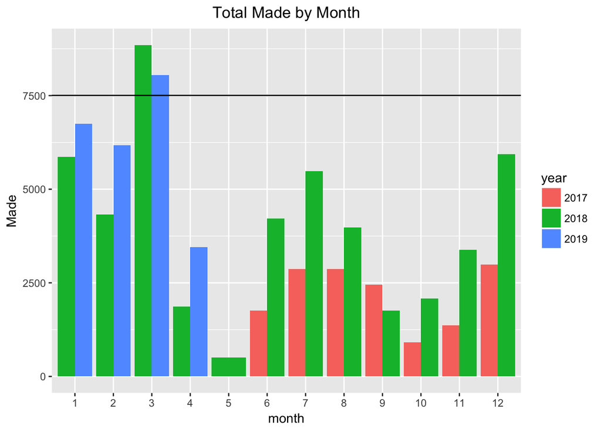

```r
made_by_month <- garfs %>%
    group_by(month) %>%
    summarise(made = sum(Made))

mean_made_by_month <- made_by_month %>%
    filter(month != month(Sys.Date())) %>%
        summarise(mean(made))

garfs %>%
    ggplot(aes(month, Made, fill = year)) +
    stat_summary(fun.y = sum, geom = "bar", position = "dodge") +
    geom_hline(aes(yintercept = mean_made_by_month)) +
    ggtitle("Total Made by Month")
```

```r
garfs %>%
    group_by(year) %>%
    summarise(sum(Made), median(Made), mean(Made), n())
```

| year | sum(Made) | median(Made) | mean(Made) | n() |
| --- | --- | --- | --- | --- |
| 2017 | 15219 | 136.0 | 149.2059 | 102 |
| 2018 | 48237 | 247.5 | 259.3387 | 186 |
| 2019 | 24423 | 310.5 | 321.3553 | 76 |

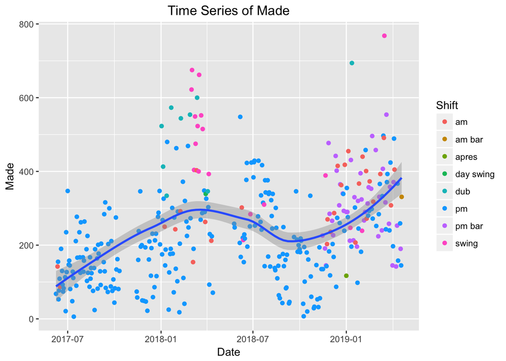

```r
garfs %>%
    ggplot(aes(Date, Made)) +
    geom_point(aes(color = Shift)) +
    geom_smooth() +
    ggtitle("Time Series of Made")
```

An outlier robust look at how much I made per shift, by month:

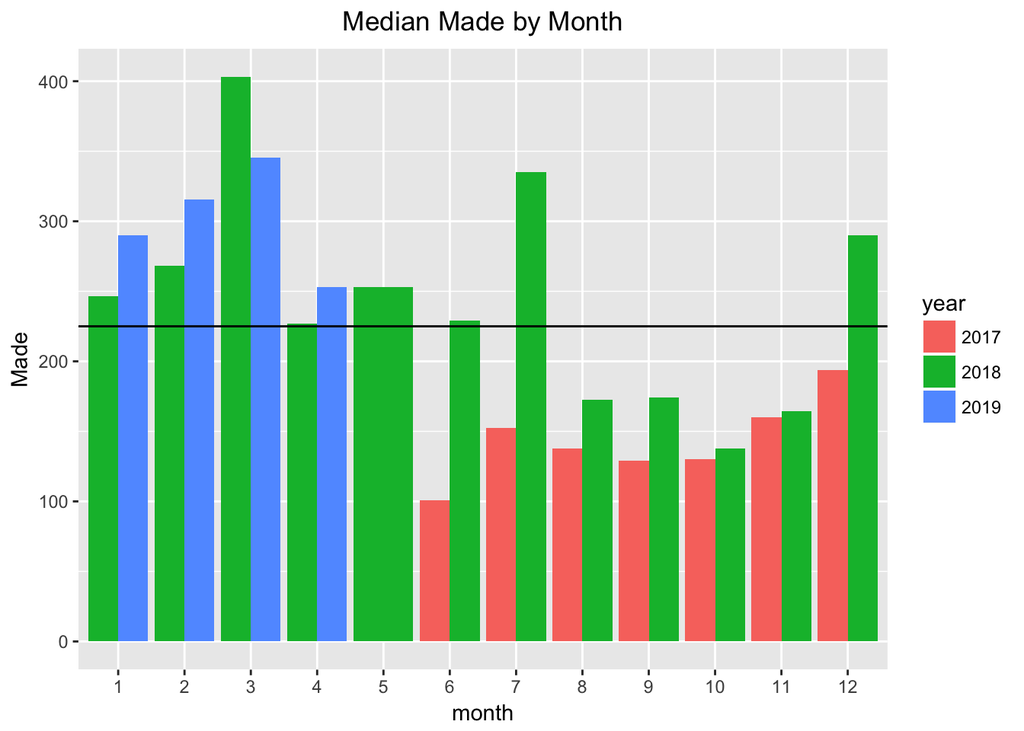

```r
garfs %>%
    ggplot(aes(month, Made, fill = year)) +
    stat_summary(fun.y = median, geom = "bar", position = "dodge") +
    geom_hline(aes(yintercept = median(Made))) +
    ggtitle("Median Made by Month")
```

A look at how much I made per shift including outliers in order to capture the full variation, by month:

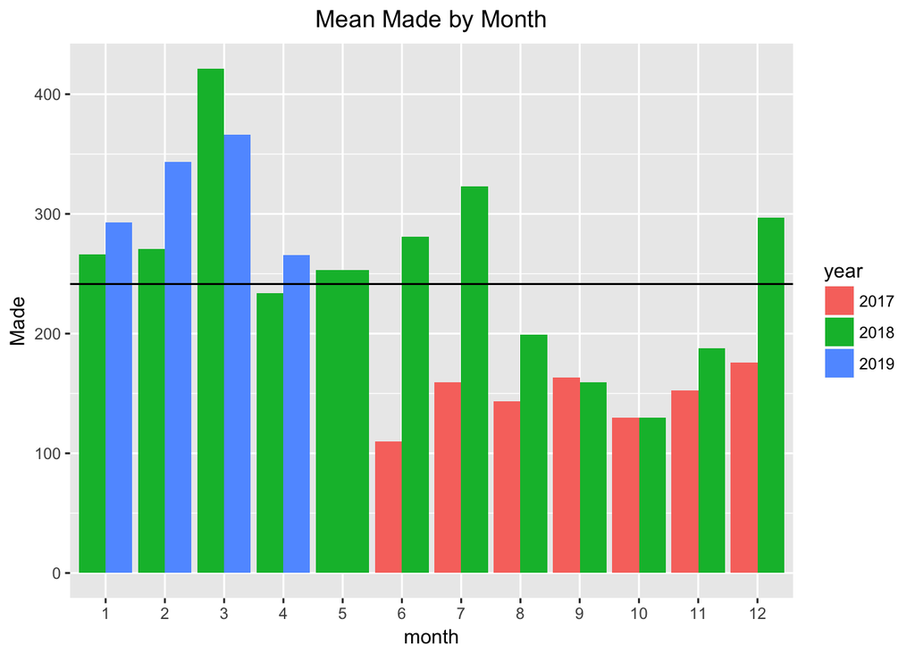

```r
garfs %>%
    ggplot(aes(month, Made, fill = year)) +
    stat_summary(fun.y = mean, geom = "bar", position = "dodge") +
    geom_hline(aes(yintercept = mean(Made))) +
    ggtitle("Mean Made by Month")
```

Monthly median and mean of total made:

```r
garfs %>%
    group_by(month) %>%
    summarise(tot = sum(Made)) %>%
    summarise(median(tot), mean(tot))
```

| median(tot) | mean(tot) |
| --- | --- |
| 6410 | 7323.25 |

```r
# same but excluding May
garfs %>%
    filter(month != 5) %>%
    group_by(month) %>%
    summarise(tot = sum(Made)) %>%
    summarise(median(tot), mean(tot))
```

| median(tot) | mean(tot) |
| --- | --- |
| 6849 | 7943 |

```r
# same but excluding May, October, November
garfs %>%
    filter(month != 5, month != 10, month != 11) %>%
    group_by(month) %>%
    summarise(tot = sum(Made)) %>%
    summarise(median(tot), mean(tot))
```

| median(tot) | mean(tot) |
| --- | --- |
| 8358 | 8848.444 |

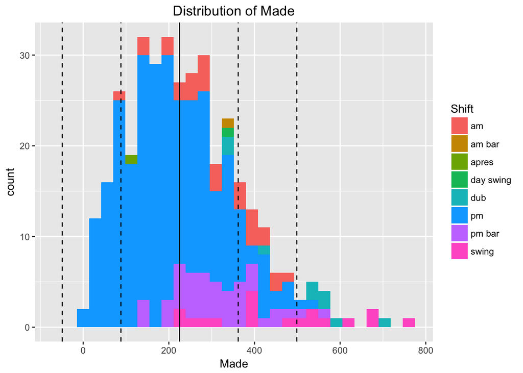

```r
garfs %>%
    ggplot(aes(Made)) +
    geom_histogram(aes(fill = Shift)) +
    geom_vline(aes(xintercept = median(Made))) +
    geom_vline(aes(xintercept = median(Made) + sd(Made)), linetype = 2) +
    geom_vline(aes(xintercept = median(Made) - sd(Made)), linetype = 2) +
    geom_vline(aes(xintercept = median(Made) + (2 * sd(Made))), linetype = 2) +
    geom_vline(aes(xintercept = median(Made) - (2* sd(Made))), linetype = 2) +
    ggtitle("Distribution of Made")
```

```r
garfs %>%
    group_by(Shift) %>%
    summarise(count = n(), percent_n = round((count / nrow(garfs) * 100), digits = 1), mean(Made), median(Made))
```

| Shift | count | percent_n | mean(Made) | median(Made) |
| --- | --- | --- | --- | --- |
| am | 29 | 8.0 | 309.3103 | 302.0 |
| am bar | 1 | 0.3 | 331.0000 | 331.0 |
| apres | 1 | 0.3 | 117.0000 | 117.0 |
| day swing | 1 | 0.3 | 339.0000 | 339.0 |
| dub | 9 | 2.5 | 509.0000 | 544.0 |
| pm | 262 | 72.0 | 198.5840 | 189.0 |
| pm bar | 43 | 11.8 | 309.0930 | 308.0 |
| swing | 18 | 4.9 | 456.7222 | 439.5 |

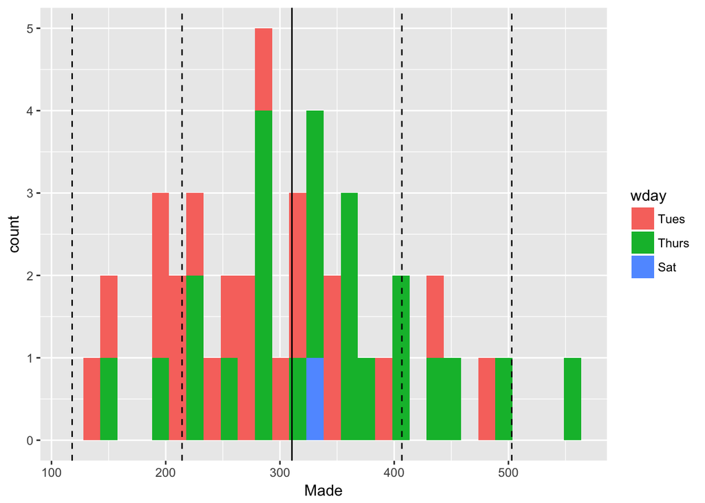

```r
garfs %>%
    filter(Shift == "pm bar" | Shift == "am bar") %>%
    ggplot(aes(Made)) +
    geom_histogram(aes(fill = wday)) +
    geom_vline(aes(xintercept = median(Made))) +
    geom_vline(aes(xintercept = median(Made) + sd(Made)), linetype = 2) +
    geom_vline(aes(xintercept = median(Made) - sd(Made)), linetype = 2) +
    geom_vline(aes(xintercept = median(Made) + (2 * sd(Made))), linetype = 2) +
    geom_vline(aes(xintercept = median(Made) - (2* sd(Made))), linetype = 2)
```

```r
garfs %>%
    filter(Shift == "pm bar" | Shift == "am bar") %>%
    group_by(wday) %>%
    summarise(count = n(), mean(Made), median(Made))
```

| wday | count | mean(Made) | median(Made) |
| --- | --- | --- | --- |
| Tues | 20 | 279.400 | 266.5 |
| Thurs | 23 | 334.913 | 330.0 |
| Sat | 1 | 331.000 | 331.0 |

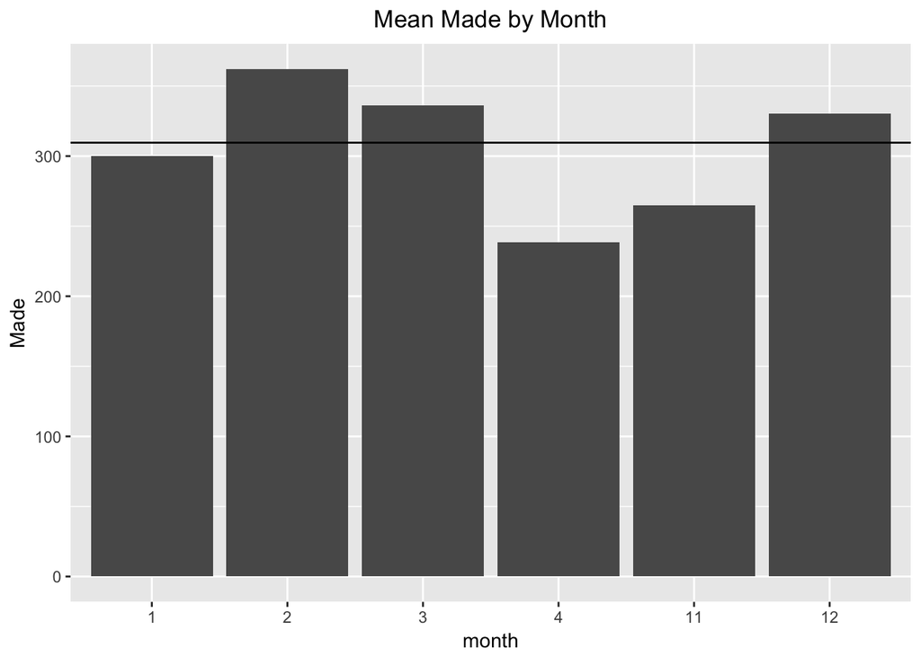

```r
garfs %>%
    filter(Shift == "pm bar" | Shift == "am bar") %>%
    ggplot(aes(month, Made)) +
    stat_summary(fun.y = mean, geom = "bar", position = "dodge") +
    geom_hline(aes(yintercept = mean(Made))) +
    ggtitle("Mean Made by Month")
```

```r
garfs %>%
    filter(Shift == "pm bar" | Shift == "am bar") %>%
    group_by(year, month) %>%
    summarise(sum(Made), median(Made), mean(Made), n()) %>%
    arrange(desc(year), desc(month))
```

| year | month | sum(Made) | median(Made) | mean(Made) | n() |
| --- | --- | --- | --- | --- | --- |
| 2019 | 4 | 1432 | 221.5 | 238.6667 | 6 |
| 2019 | 3 | 2688 | 323.5 | 336.0000 | 8 |
| 2019 | 2 | 2534 | 353.0 | 362.0000 | 7 |
| 2019 | 1 | 3001 | 305.0 | 300.1000 | 10 |
| 2018 | 12 | 2643 | 324.0 | 330.3750 | 8 |
| 2018 | 11 | 1324 | 226.0 | 264.8000 | 5 |

A look at Winter 18-19

```r
garfs %>%
    filter((year == 2018 & month %in% c(11, 12)) | (year == 2019 & month %in% c(1, 2, 3, 4))) %>%
    summarise(median(Made), mean(Made), n(), sum(Made))
```

| median(Made) | mean(Made) | n() | sum(Made) |
| --- | --- | --- | --- |
| 288.5 | 295.9298 | 114 | 33736 |

```r
garfs %>%
    filter((year == 2018 & month %in% c(12)) | (year == 2019 & month %in% c(1, 2, 3, 4))) %>%
    summarise(median(Made), mean(Made), n(), sum(Made))
```

| median(Made) | mean(Made) | n() | sum(Made) |
| --- | --- | --- | --- |
| 305 | 316.1979 | 96 | 30355 |

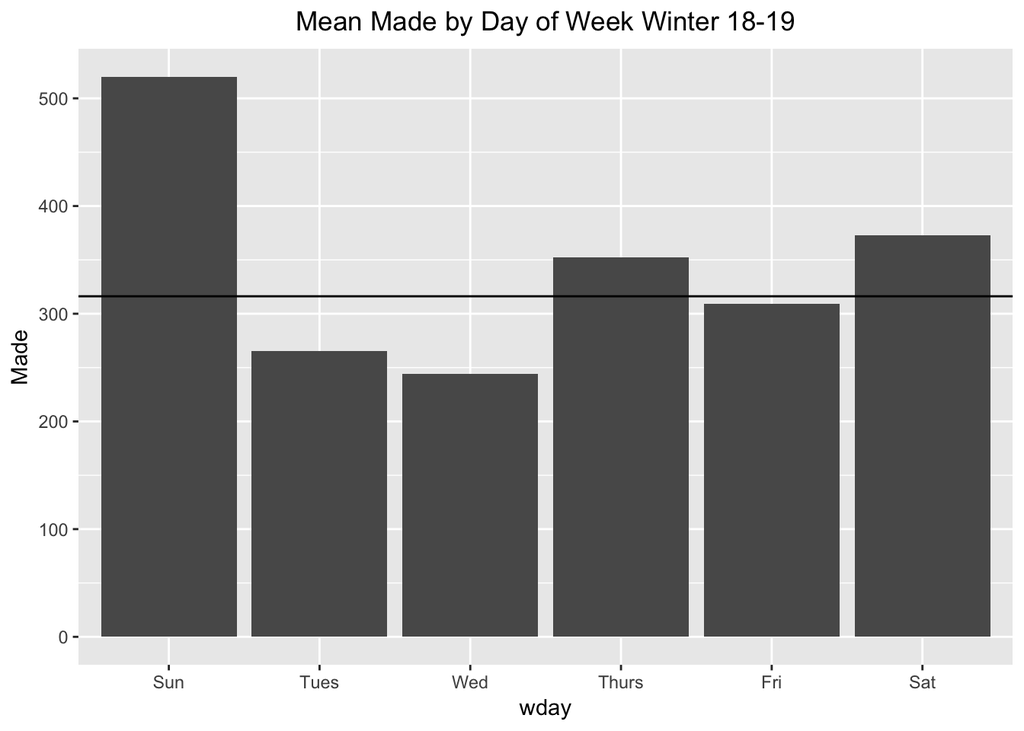

```r
garfs %>%
    filter((year == 2018 & month %in% c(12)) | (year == 2019 & month %in% c(1, 2, 3, 4))) %>%
    group_by(wday) %>%
    ggplot(aes(wday, Made)) +
    stat_summary(fun.y = mean, geom = "bar", position = "dodge") +
    geom_hline(aes(yintercept = mean(Made))) +
    ggtitle("Mean Made by Day of Week Winter 18-19")
```

```r
garfs %>%
    filter((year == 2018 & month %in% c(12)) | (year == 2019 & month %in% c(1, 2, 3, 4))) %>%
    group_by(wday) %>%
    summarise(median(Made), mean(Made), n(), sum(Made))
```

| wday | median(Made) | mean(Made) | n() | sum(Made) |
| --- | --- | --- | --- | --- |
| Sun | 520 | 520.0000 | 2 | 1040 |
| Tues | 266 | 265.1053 | 19 | 5037 |
| Wed | 253 | 244.0625 | 16 | 3905 |
| Thurs | 344 | 352.3500 | 20 | 7047 |
| Fri | 276 | 309.1053 | 19 | 5873 |
| Sat | 383 | 372.6500 | 20 | 7453 |

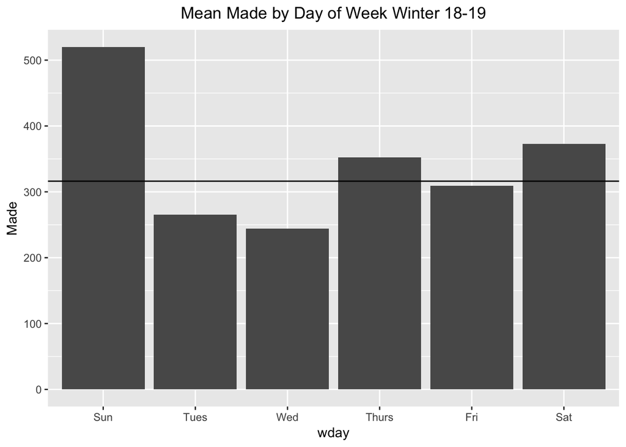

```r
garfs %>%
    filter((year == 2018 & month %in% c(12)) | (year == 2019 & month %in% c(1, 2, 3, 4))) %>%
    group_by(wday) %>%
    ggplot(aes(wday, Made)) +
    stat_summary(fun.y = mean, geom = "bar", position = "dodge") +
    geom_hline(aes(yintercept = mean(Made))) +
    ggtitle("Mean Made by Day of Week Winter 18-19")
```

```r
garfs %>%
    filter((year == 2018 & month %in% c(12)) | (year == 2019 & month %in% c(1, 2, 3, 4))) %>%
    group_by(wday) %>%
    summarise(median(Made), mean(Made), n(), sum(Made))
```

| wday | median(Made) | mean(Made) | n() | sum(Made) |
| --- | --- | --- | --- | --- |
| Sun | 520 | 520.0000 | 2 | 1040 |
| Tues | 266 | 265.1053 | 19 | 5037 |
| Wed | 253 | 244.0625 | 16 | 3905 |
| Thurs | 344 | 352.3500 | 20 | 7047 |
| Fri | 276 | 309.1053 | 19 | 5873 |
| Sat | 383 | 372.6500 | 20 | 7453 |

Distribution of Made Winter 18-19

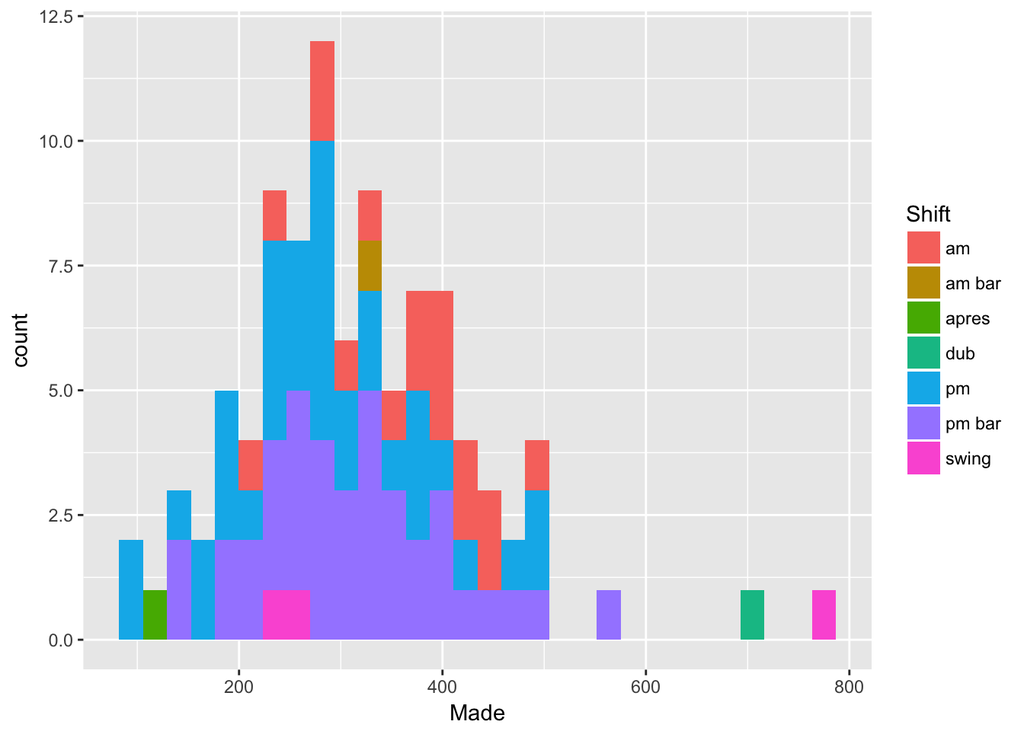

```r
garfs %>%
    filter((year == 2018 & month %in% c(12)) | (year == 2019 & month %in% c(1, 2, 3, 4))) %>%
    ggplot(aes(Made, fill = Shift)) +
    geom_histogram()
```

A look at Summer 2018

```r
garfs %>%
    filter(year == 2018, month %in% c(5, 6, 7, 8, 9)) %>%
    summarise(median(Made), mean(Made), n(), sum(Made))
```

| median(Made) | mean(Made) | n() | sum(Made) |
| --- | --- | --- | --- |
| 245 | 245.2769 | 65 | 15943 |

```r
garfs %>%
    filter(year == 2018, month %in% c(5, 6, 7, 8)) %>%
    summarise(median(Made), mean(Made), n(), sum(Made))
```

| median(Made) | mean(Made) | n() | sum(Made) |
| --- | --- | --- | --- |
| 252 | 262.7407 | 54 | 14188 |

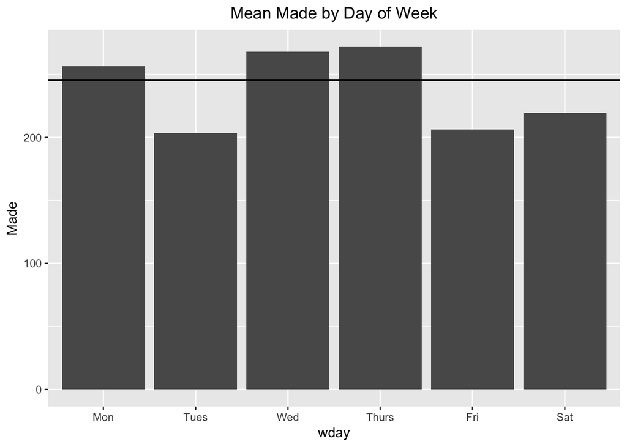

```r
garfs %>%
    filter(year == 2018, month %in% c(5, 6, 7, 8, 9)) %>%
    group_by(wday) %>%
    ggplot(aes(wday, Made)) +
    stat_summary(fun.y = mean, geom = "bar", position = "dodge") +
    geom_hline(aes(yintercept = mean(Made))) +
    ggtitle("Mean Made by Day of Week")
```

```r
garfs %>%
    filter(year == 2018, month %in% c(5, 6, 7, 8, 9)) %>%
    group_by(wday) %>%
    summarise(median(Made), mean(Made), n(), sum(Made))
```

| wday | median(Made) | mean(Made) | n() | sum(Made) |
| --- | --- | --- | --- | --- |
| Mon | 263.0 | 256.3846 | 13 | 3333 |
| Tues | 187.5 | 203.2857 | 14 | 2846 |
| Wed | 243.5 | 268.0714 | 14 | 3753 |
| Thurs | 249.0 | 271.6667 | 15 | 4075 |
| Fri | 218.0 | 206.3333 | 3 | 619 |
| Sat | 224.0 | 219.5000 | 6 | 1317 |

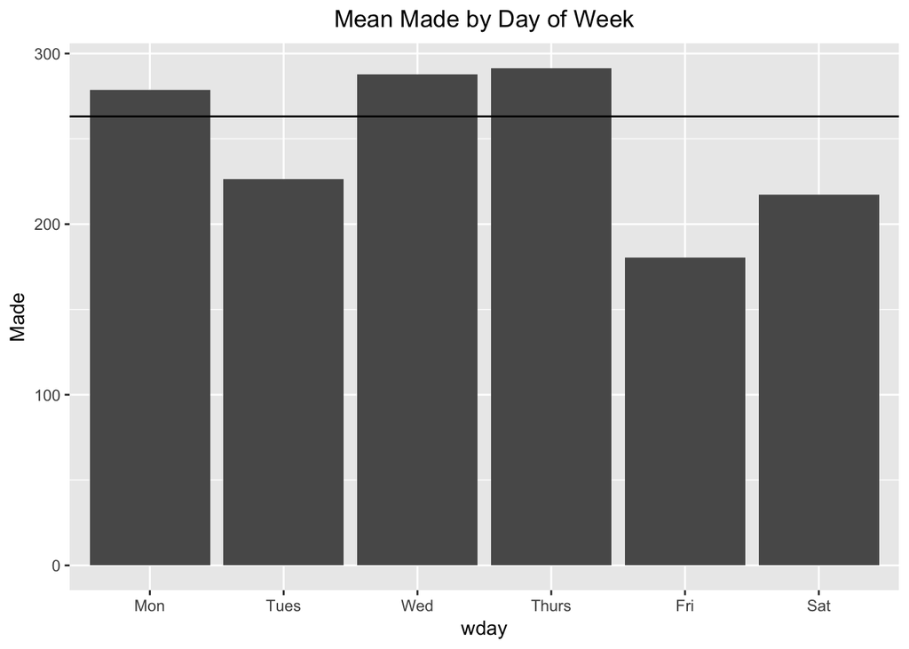

```r
garfs %>%
    filter(year == 2018, month %in% c(6, 7, 8)) %>%
    group_by(wday) %>%
    ggplot(aes(wday, Made)) +
    stat_summary(fun.y = mean, geom = "bar", position = "dodge") +
    geom_hline(aes(yintercept = mean(Made))) +
    ggtitle("Mean Made by Day of Week")
```

```r
garfs %>%
    filter(year == 2018, month %in% c(6, 7, 8)) %>%
    group_by(wday) %>%
    summarise(median(Made), mean(Made), n(), sum(Made))
```

| wday | median(Made) | mean(Made) | n() | sum(Made) |
| --- | --- | --- | --- | --- |
| Mon | 286.5 | 278.5000 | 10 | 2785 |
| Tues | 210.0 | 226.4167 | 12 | 2717 |
| Wed | 261.5 | 287.7500 | 12 | 3453 |
| Thurs | 296.0 | 291.4167 | 12 | 3497 |
| Fri | 180.5 | 180.5000 | 2 | 361 |
| Sat | 222.0 | 217.2500 | 4 | 869 |

Distribution of Made during Summer 2018

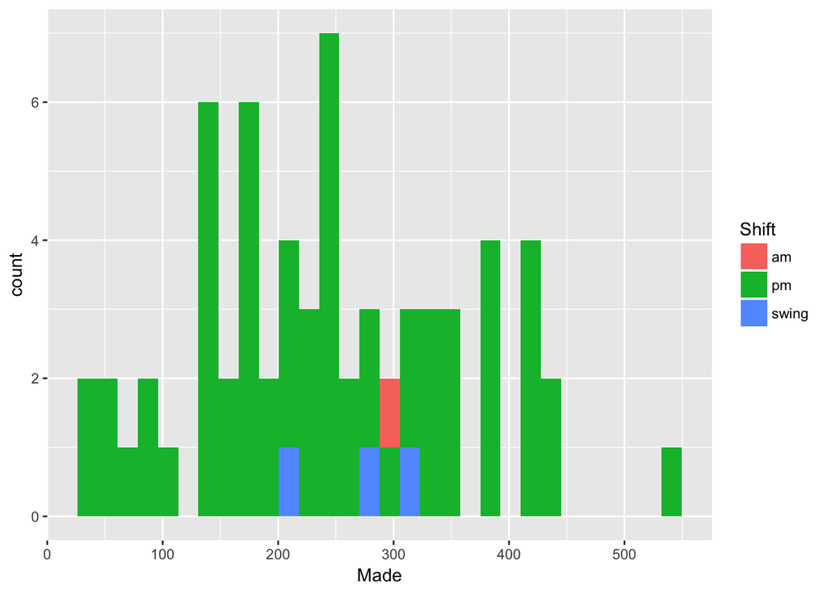

```r
garfs %>%
    filter(year == 2018, month %in% c(5, 6, 7, 8, 9)) %>%
    ggplot(aes(Made, fill = Shift)) +
    geom_histogram()
```

Total sales since I began tracking

```r
garfs %>%
    summarise(sum(LittleNumber, na.rm = TRUE))
```

| sum(LittleNumber, na.rm = TRUE) |
| --- |
| 431244.8 |

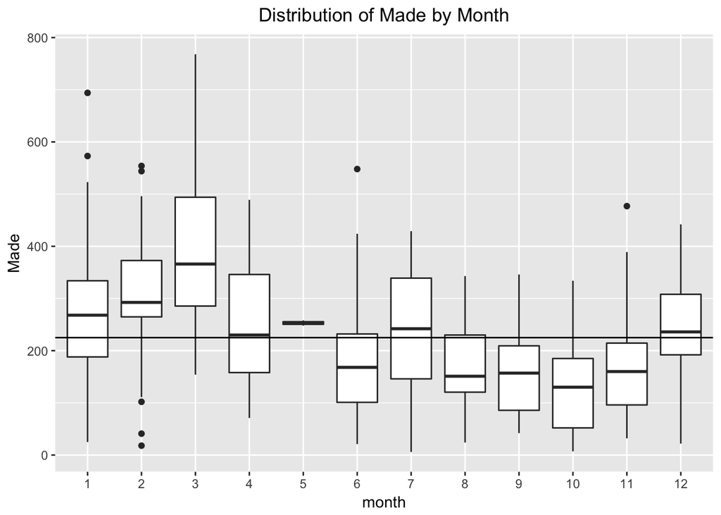

```r
garfs %>%
    ggplot(aes(month, Made)) +
    geom_boxplot() +
    geom_hline(aes(yintercept = median(Made))) +
    ggtitle("Distribution of Made by Month")
```

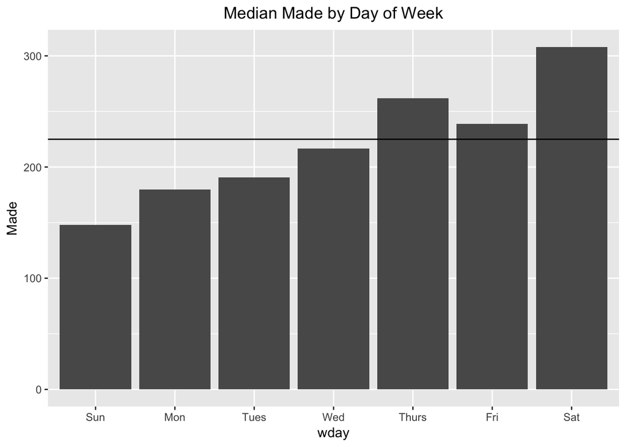

```r
garfs %>%
    ggplot(aes(wday, Made)) +
    stat_summary(fun.y = median, geom = "bar") +
    geom_hline(aes(yintercept = median(Made))) +
    ggtitle("Median Made by Day of Week")
```

```r
garfs %>%
    group_by(wday) %>%
    summarise(median(Made), mean(Made), n())
```

| wday | median(Made) | mean(Made) | n() |
| --- | --- | --- | --- |
| Sun | 148.0 | 232.7500 | 12 |
| Mon | 180.0 | 195.6154 | 39 |
| Tues | 190.5 | 207.1667 | 78 |
| Wed | 216.5 | 229.5278 | 72 |
| Thurs | 262.0 | 258.3279 | 61 |
| Fri | 239.0 | 262.6471 | 51 |
| Sat | 308.0 | 306.2549 | 51 |

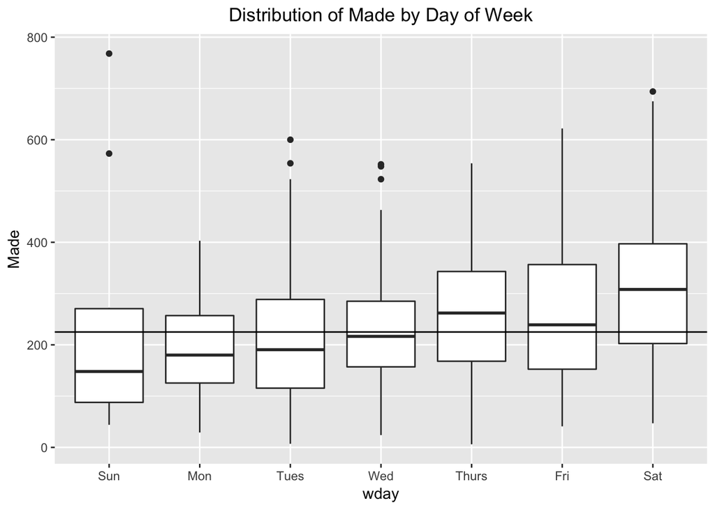

```r
garfs %>%
    ggplot(aes(wday, Made)) +
    geom_boxplot() +
    geom_hline(aes(yintercept = median(Made))) +
    ggtitle("Distribution of Made by Day of Week")
```

When identifying outliers, I will arbitrarily call anything lower than **50** or higher than **300** an outlier.

```r
garfs %>%
    filter(Made < 50)
```

| Date | BigNumber | LittleNumber | NegDrop | Dinner | Shift | CutTime | Made | Comments | NegDropPaid(1/0) | percent_little | percent_big | month | year | wday |
| --- | --- | --- | --- | --- | --- | --- | --- | --- | --- | --- | --- | --- | --- | --- |
| 2017-06-27 | 174.57 | NA | NA | 1 | pm | 6 | 21 | cut early | NA | NA | 0.1202956 | 6 | 2017 | Tues |
| 2017-07-10 | 379.48 | 369.50 | NA | 0 | pm | NA | 48 | NA | NA | 0.12990528 | 0.1264889 | 7 | 2017 | Mon |
| 2017-07-13 | 55.30 | 71.00 | -11.00 | 0 | pm | 5 | 6 | cut early | NA | 0.08450704 | 0.1084991 | 7 | 2017 | Thurs |
| 2017-08-23 | 158.28 | 124.00 | NA | 0 | pm | 6 | 24 | cut early | NA | 0.19354839 | 0.1516300 | 8 | 2017 | Wed |
| 2017-10-01 | 333.95 | 308.03 | NA | 0 | pm | 6 | 44 | cut early | NA | 0.14284323 | 0.1317563 | 10 | 2017 | Sun |
| 2017-11-28 | 345.29 | 357.00 | NA | 1 | pm | NA | 49 | NA | NA | 0.13725490 | 0.1419097 | 11 | 2017 | Tues |
| 2017-12-02 | 336.36 | 348.25 | -56.49 | 1 | pm | 7 | 47 | cut early | 1 | 0.13496052 | 0.1397312 | 12 | 2017 | Sat |
| 2017-12-05 | 75.89 | 70.00 | NA | 0 | pm | 6 | 22 | cut earluy | NA | 0.31428571 | 0.2898933 | 12 | 2017 | Tues |
| 2018-01-16 | 149.88 | 144.25 | NA | 0 | pm | 6 | 25 | cut super early | NA | 0.17331023 | 0.1668001 | 1 | 2018 | Tues |
| 2018-02-06 | 124.68 | 115.00 | -24.80 | 0 | pm | 6 | 18 | cut super early | 1 | 0.15652174 | 0.1443696 | 2 | 2018 | Tues |

[output cut: 10 more lines]

```r
garfs %>%
    filter(Made > 300)
```

| Date | BigNumber | LittleNumber | NegDrop | Dinner | Shift | CutTime | Made | Comments | NegDropPaid(1/0) | percent_little | percent_big | month | year | wday |
| --- | --- | --- | --- | --- | --- | --- | --- | --- | --- | --- | --- | --- | --- | --- |
| 2017-07-01 | 1756.57 | 1624.00 | NA | 0 | pm | NA | 347 | NA | NA | 0.2136700 | 0.19754408 | 7 | 2017 | Sat |
| 2017-09-13 | 1746.86 | 1570.25 | -158.83 | 0 | pm | NA | 316 | NA | 1 | 0.2012418 | 0.18089601 | 9 | 2017 | Wed |
| 2017-11-21 | 1539.68 | 1420.25 | -307.78 | 0 | pm | NA | 346 | Big party | 1 | 0.2436191 | 0.22472202 | 11 | 2017 | Tues |
| 2017-12-29 | 1867.13 | 1761.00 | NA | 0 | pm | NA | 347 | NA | NA | 0.1970471 | 0.18584673 | 12 | 2017 | Fri |
| 2018-01-02 | 3775.63 | 3506.75 | -278.64 | 1 | dub | NA | 523 | double | 1 | 0.1491409 | 0.13851993 | 1 | 2018 | Tues |
| 2018-01-05 | 2968.32 | 2755.00 | NA | 0 | dub | NA | 413 | NA | NA | 0.1499093 | 0.13913594 | 1 | 2018 | Fri |
| 2018-01-06 | 1994.19 | 1814.50 | NA | 0 | pm | NA | 326 | NA | NA | 0.1796638 | 0.16347489 | 1 | 2018 | Sat |
| 2018-01-12 | 2591.36 | 2417.50 | NA | 0 | dub | NA | 334 | double but cut around 7 | NA | 0.1381593 | 0.12888985 | 1 | 2018 | Fri |
| 2018-01-13 | 2026.43 | 1880.25 | -97.62 | 0 | pm | NA | 480 | apres | 1 | 0.2552852 | 0.23686977 | 1 | 2018 | Sat |
| 2018-01-21 | 3735.21 | 3561.25 | -34.66 | 0 | dub | NA | 573 | double | 1 | 0.1608986 | 0.15340503 | 1 | 2018 | Sun |

[output cut: 99 more lines]

## Now a look at how much I made as a **percentage of sales**:

```r
summary(garfs$percent_little)
```

```
##    Min. 1st Qu.  Median    Mean 3rd Qu.    Max.    NA's
## 0.08451 0.14510 0.16040 0.16750 0.17960 0.47480      62
```

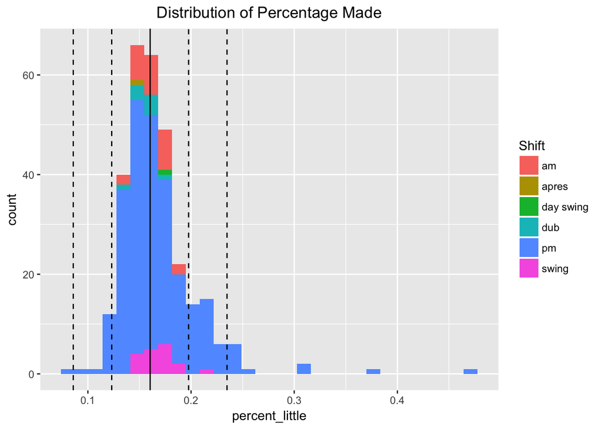

```r
garfs %>%
    ggplot(aes(percent_little)) +
    geom_histogram(aes(fill = Shift)) +
    geom_vline(aes(xintercept = median(percent_little, na.rm = TRUE))) +
    geom_vline(aes(xintercept = median(percent_little, na.rm = TRUE) + sd(percent_little, na.rm = TRUE)), linetype = 2) +
    geom_vline(aes(xintercept = median(percent_little, na.rm = TRUE) - sd(percent_little, na.rm = TRUE)), linetype = 2) +
    geom_vline(aes(xintercept = median(percent_little, na.rm = TRUE) + (2 * sd(percent_little, na.rm = TRUE))), linetype = 2) +
    geom_vline(aes(xintercept = median(percent_little, na.rm = TRUE) - (2 * sd(percent_little, na.rm = TRUE))), linetype = 2) +
    ggtitle("Distribution of Percentage Made")
```

```r
garfs %>%
    summarise(median(percent_little, na.rm = TRUE), mean(percent_little, na.rm = TRUE))
```

| median(percent_little, na.rm = TRUE) | mean(percent_little, na.rm = TRUE) |
| --- | --- |
| 0.1603526 | 0.1674944 |

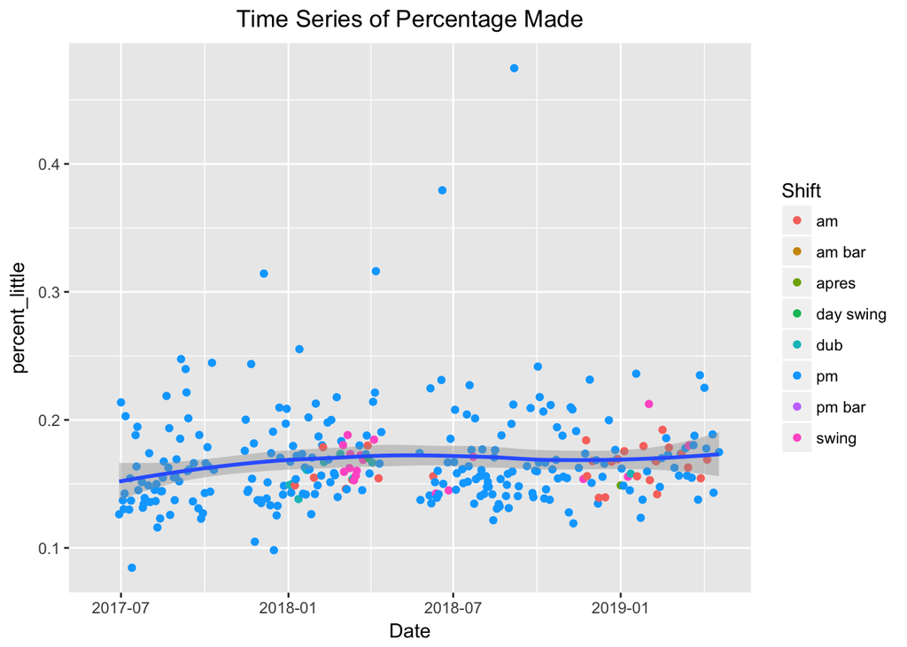

```r
garfs %>%
    ggplot(aes(Date, percent_little)) +
    geom_point(aes(color = Shift)) +
    geom_smooth() +
    ggtitle("Time Series of Percentage Made")
```

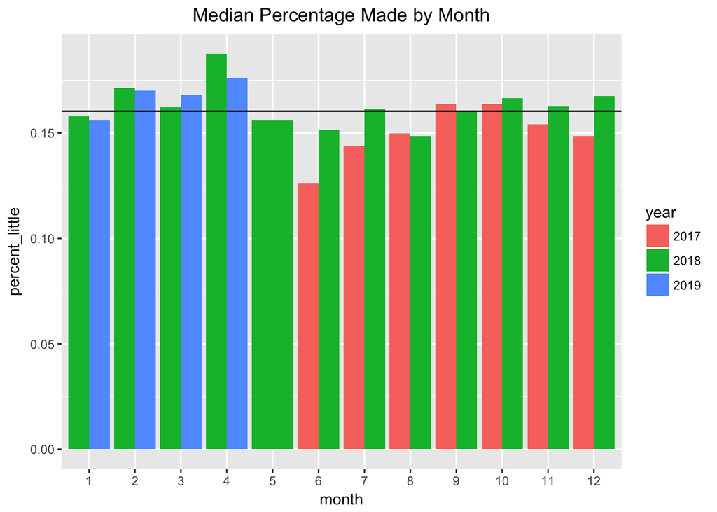

```r
garfs %>%
    ggplot(aes(month, percent_little, fill = year)) +
    stat_summary(fun.y = median, geom = "bar", position = "dodge") +
    geom_hline(aes(yintercept = median(percent_little, na.rm = TRUE))) +
    ggtitle("Median Percentage Made by Month")
```

```r
garfs %>%
    group_by(year, month) %>%
    summarise(Median = median(percent_little, na.rm = TRUE), Mean = mean(percent_little, na.rm = TRUE))
```

| year | month | Median | Mean |
| --- | --- | --- | --- |
| 2017 | 6 | 0.1262425 | 0.1262425 |
| 2017 | 7 | 0.1437880 | 0.1515753 |
| 2017 | 8 | 0.1498751 | 0.1531407 |
| 2017 | 9 | 0.1637862 | 0.1742878 |
| 2017 | 10 | 0.1637902 | 0.1715578 |
| 2017 | 11 | 0.1540578 | 0.1651777 |
| 2017 | 12 | 0.1485302 | 0.1651019 |
| 2018 | 1 | 0.1578871 | 0.1639887 |
| 2018 | 2 | 0.1712389 | 0.1728709 |
| 2018 | 3 | 0.1623540 | 0.1651489 |

[output cut: 13 more lines]

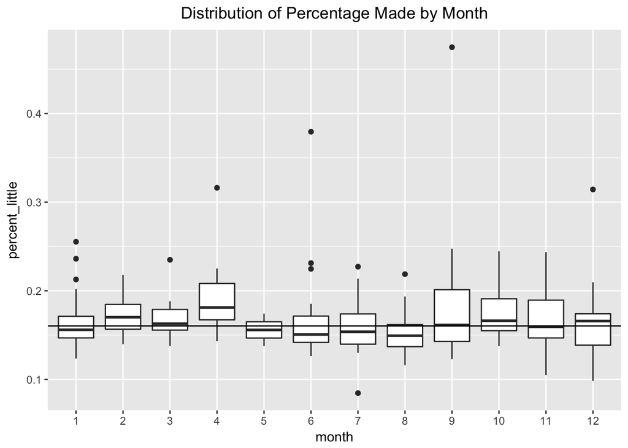

```r
garfs %>%
    ggplot(aes(month, percent_little)) +
    geom_boxplot() +
    geom_hline(aes(yintercept = median(percent_little, na.rm = TRUE))) +
    ggtitle("Distribution of Percentage Made by Month")
```

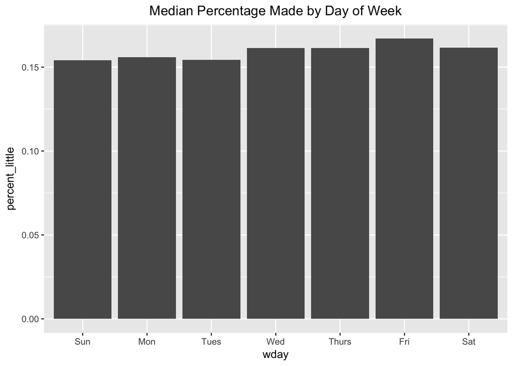

```r
garfs %>%
    ggplot(aes(wday, percent_little)) +
    stat_summary(fun.y = median, geom = "bar") +
#    geom_hline(aes(yintercept = median(percent_little, na.rm = TRUE))) +
    ggtitle("Median Percentage Made by Day of Week")
```

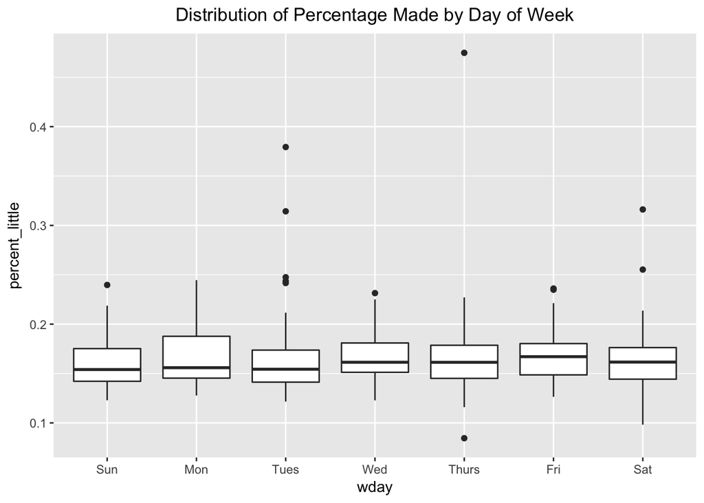

```r
garfs %>%
    ggplot(aes(wday, percent_little)) +
    geom_boxplot() +
#    geom_hline(aes(yintercept = median(percent_little, na.rm = TRUE))) +
    ggtitle("Distribution of Percentage Made by Day of Week")
```

When identifying outliers, I will arbitrarily call anything lower than **.13** or higher than **.23** an outlier.

```r
garfs %>%
    filter(percent_little < .13)
```

| Date | BigNumber | LittleNumber | NegDrop | Dinner | Shift | CutTime | Made | Comments | NegDropPaid(1/0) | percent_little | percent_big | month | year | wday |
| --- | --- | --- | --- | --- | --- | --- | --- | --- | --- | --- | --- | --- | --- | --- |
| 2017-06-29 | 1082.58 | 1006.00 | NA | 1 | pm | NA | 127 | NA | NA | 0.12624254 | 0.11731235 | 6 | 2017 | Thurs |
| 2017-07-10 | 379.48 | 369.50 | NA | 0 | pm | NA | 48 | NA | NA | 0.12990528 | 0.12648888 | 7 | 2017 | Mon |
| 2017-07-13 | 55.30 | 71.00 | -11.00 | 0 | pm | 5 | 6 | cut early | NA | 0.08450704 | 0.10849910 | 7 | 2017 | Thurs |
| 2017-08-10 | 1160.00 | 1078.00 | -52.06 | 1 | pm | NA | 125 | NA | 1 | 0.11595547 | 0.10775862 | 8 | 2017 | Thurs |
| 2017-08-13 | 760.64 | 707.50 | -30.81 | 1 | pm | NA | 87 | NA | 1 | 0.12296820 | 0.11437737 | 8 | 2017 | Sun |
| 2017-08-24 | 1620.46 | 1502.75 | NA | 1 | pm | NA | 189 | NA | NA | 0.12576942 | 0.11663355 | 8 | 2017 | Thurs |
| 2017-09-27 | 634.25 | 619.00 | -93.67 | 0 | pm | NA | 76 | NA | 1 | 0.12277868 | 0.11982657 | 9 | 2017 | Wed |
| 2017-09-29 | 906.83 | 842.04 | -94.22 | 1 | pm | NA | 107 | NA | 1 | 0.12707235 | 0.11799345 | 9 | 2017 | Fri |
| 2017-11-25 | 508.45 | 477.00 | -72.52 | 1 | pm | NA | 50 | less 23 iou (I think) | 1 | 0.10482180 | 0.09833809 | 11 | 2017 | Sat |
| 2017-12-16 | 601.79 | 600.75 | -12.47 | 0 | pm | NA | 59 | NA | 1 | 0.09821057 | 0.09804084 | 12 | 2017 | Sat |

[output cut: 6 more lines]

```r
garfs %>%
    filter(percent_little > .23)
```

| Date | BigNumber | LittleNumber | NegDrop | Dinner | Shift | CutTime | Made | Comments | NegDropPaid(1/0) | percent_little | percent_big | month | year | wday |
| --- | --- | --- | --- | --- | --- | --- | --- | --- | --- | --- | --- | --- | --- | --- |
| 2017-09-05 | 885.07 | 824.25 | NA | 0 | pm | NA | 204 | NA | NA | 0.2474977 | 0.2304902 | 9 | 2017 | Tues |
| 2017-09-10 | 687.86 | 642.50 | NA | 1 | pm | NA | 154 | NA | NA | 0.2396887 | 0.2238828 | 9 | 2017 | Sun |
| 2017-10-09 | 427.24 | 331.17 | -79.00 | 0 | pm | NA | 81 | NA | 1 | 0.2445874 | 0.1895890 | 10 | 2017 | Mon |
| 2017-11-21 | 1539.68 | 1420.25 | -307.78 | 0 | pm | NA | 346 | Big party | 1 | 0.2436191 | 0.2247220 | 11 | 2017 | Tues |
| 2017-12-05 | 75.89 | 70.00 | NA | 0 | pm | 6 | 22 | cut earluy | NA | 0.3142857 | 0.2898933 | 12 | 2017 | Tues |
| 2018-01-13 | 2026.43 | 1880.25 | -97.62 | 0 | pm | NA | 480 | apres | 1 | 0.2552852 | 0.2368698 | 1 | 2018 | Sat |
| 2018-04-07 | 1188.16 | 727.50 | NA | 1 | pm | NA | 230 | two big transfers when Sean got cut and two big double grats | NA | 0.3161512 | 0.1935766 | 4 | 2018 | Sat |
| 2018-06-18 | 1745.15 | 1630.75 | -51.00 | 0 | pm | NA | 377 | 51 from party coming on drop check | 1 | 0.2311820 | 0.2160273 | 6 | 2018 | Mon |
| 2018-06-19 | 1179.50 | 1115.00 | -105.56 | 0 | pm | NA | 423 | also -168 drop from big party | 1 | 0.3793722 | 0.3586265 | 6 | 2018 | Tues |
| 2018-09-06 | 388.13 | 366.50 | -14.08 | 1 | pm | NA | 174 | big party on party tabs with dove | NA | 0.4747613 | 0.4483034 | 9 | 2018 | Thurs |

[output cut: 4 more lines]

## Now to remove some of the noise of percentage made by looking at **sales**:

```r
summary(garfs$LittleNumber)
```

```
##    Min. 1st Qu.  Median    Mean 3rd Qu.    Max.    NA's
##    50.5   842.0  1308.0  1428.0  1873.0  4392.0      62
```

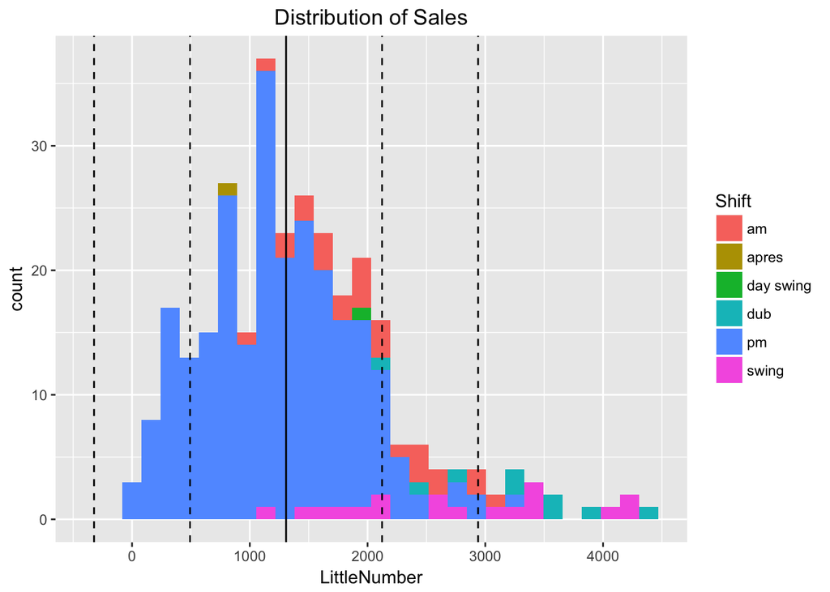

```r
garfs %>%
    ggplot(aes(LittleNumber)) +
    geom_histogram(aes(fill = Shift)) +
    geom_vline(aes(xintercept = median(LittleNumber, na.rm = TRUE))) +
    geom_vline(aes(xintercept = median(LittleNumber, na.rm = TRUE) + sd(LittleNumber, na.rm = TRUE)), linetype = 2) +
    geom_vline(aes(xintercept = median(LittleNumber, na.rm = TRUE) - sd(LittleNumber, na.rm = TRUE)), linetype = 2) +
    geom_vline(aes(xintercept = median(LittleNumber, na.rm = TRUE) + (2 * sd(LittleNumber, na.rm = TRUE))), linetype = 2) +
    geom_vline(aes(xintercept = median(LittleNumber, na.rm = TRUE) - (2 * sd(LittleNumber, na.rm = TRUE))), linetype = 2) +
    ggtitle("Distribution of Sales")
```

```r
garfs %>%
    summarise(median(LittleNumber, na.rm = TRUE), mean(LittleNumber, na.rm = TRUE))
```

| median(LittleNumber, na.rm = TRUE) | mean(LittleNumber, na.rm = TRUE) |
| --- | --- |
| 1307.965 | 1427.963 |

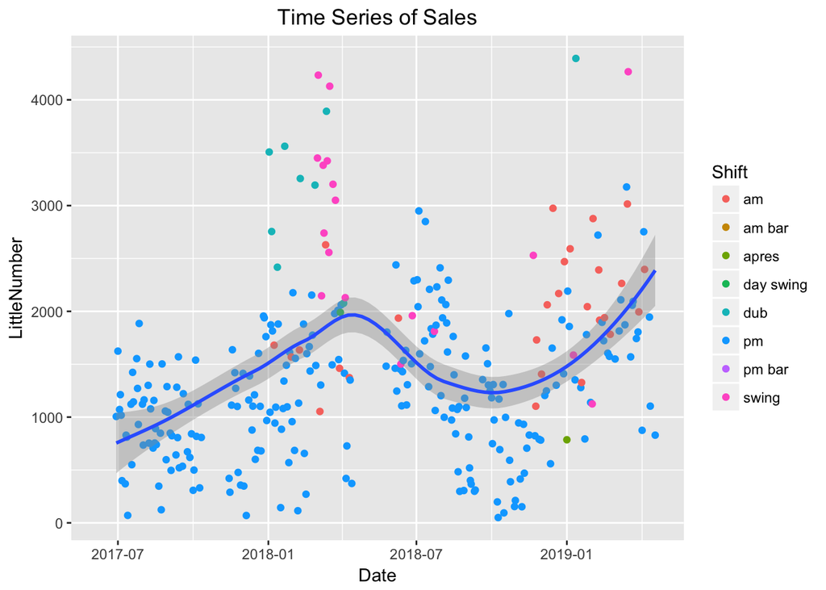

```r
garfs %>%
    ggplot(aes(Date, LittleNumber)) +
    geom_point(aes(color = Shift)) +
    geom_smooth() +
    ggtitle("Time Series of Sales")
```

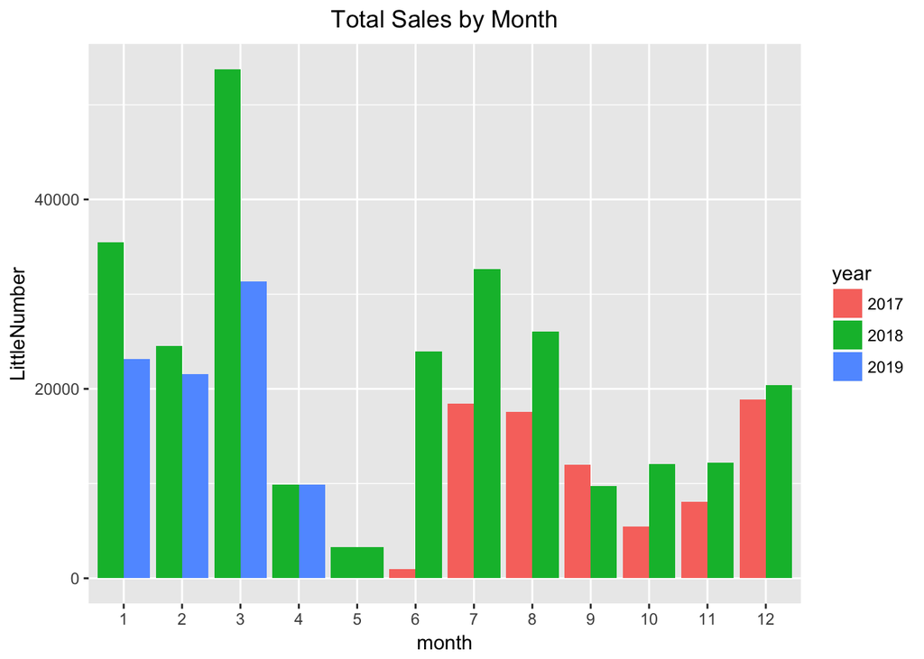

```r
garfs %>%
    ggplot(aes(month, LittleNumber, fill = year)) +
    stat_summary(fun.y = sum, geom = "bar", position = "dodge") +
#    geom_hline(aes(yintercept = median(LittleNumber, na.rm = TRUE))) +
    ggtitle("Total Sales by Month")
```

```r
garfs %>%
    group_by(year, month) %>%
    summarise(sum(LittleNumber, na.rm = TRUE), n())
```

| year | month | sum(LittleNumber, na.rm = TRUE) | n() |
| --- | --- | --- | --- |
| 2017 | 6 | 1006.00 | 16 |
| 2017 | 7 | 18407.50 | 18 |
| 2017 | 8 | 17597.00 | 20 |
| 2017 | 9 | 12002.79 | 15 |
| 2017 | 10 | 5429.36 | 7 |
| 2017 | 11 | 8088.00 | 9 |
| 2017 | 12 | 18870.75 | 17 |
| 2018 | 1 | 35496.00 | 22 |
| 2018 | 2 | 24500.00 | 16 |
| 2018 | 3 | 53732.42 | 21 |

[output cut: 13 more lines]

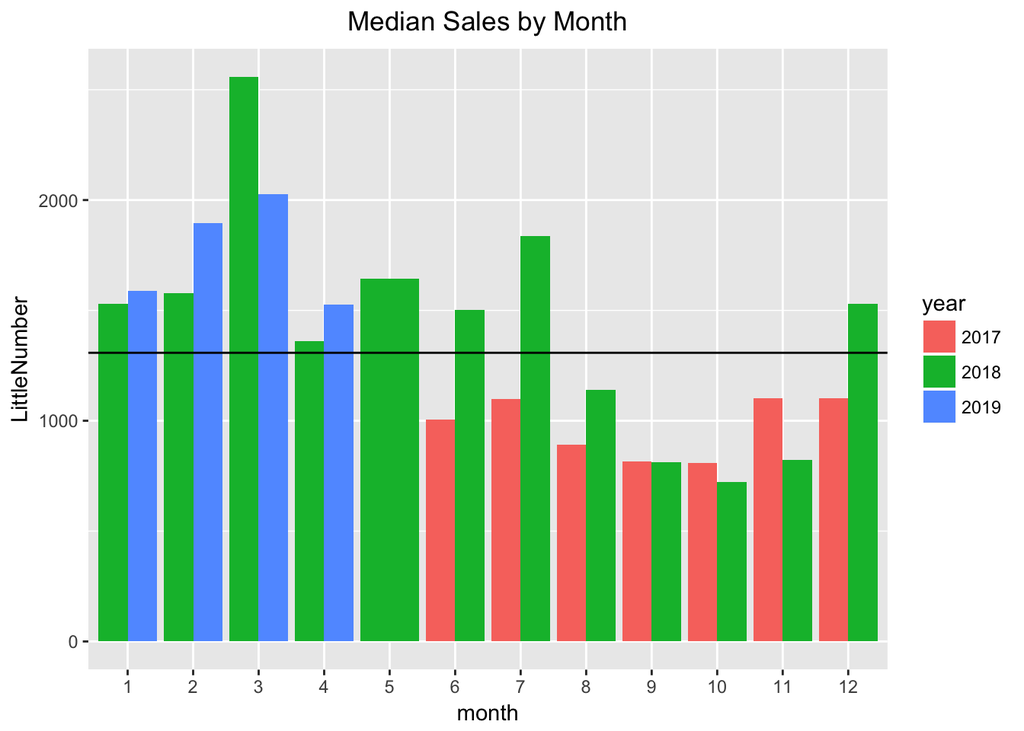

```r
garfs %>%
    ggplot(aes(month, LittleNumber, fill = year)) +
    stat_summary(fun.y = median, geom = "bar", position = "dodge") +
    geom_hline(aes(yintercept = median(LittleNumber, na.rm = TRUE))) +
    ggtitle("Median Sales by Month")
```

```r
garfs %>%
    group_by(month) %>%
    summarise(median(LittleNumber, na.rm = TRUE), mean(LittleNumber, na.rm = TRUE))
```

| month | median(LittleNumber, na.rm = TRUE) | mean(LittleNumber, na.rm = TRUE) |
| --- | --- | --- |
| 1 | 1569.000 | 1674.7409 |
| 2 | 1666.750 | 1705.6481 |
| 3 | 2094.250 | 2430.4334 |
| 4 | 1361.750 | 1412.0893 |
| 5 | 1642.750 | 1642.7500 |
| 6 | 1481.750 | 1557.6094 |
| 7 | 1423.250 | 1458.6357 |
| 8 | 1078.000 | 1119.9167 |
| 9 | 812.500 | 871.0444 |
| 10 | 749.010 | 760.0678 |

[output cut: 2 more lines]

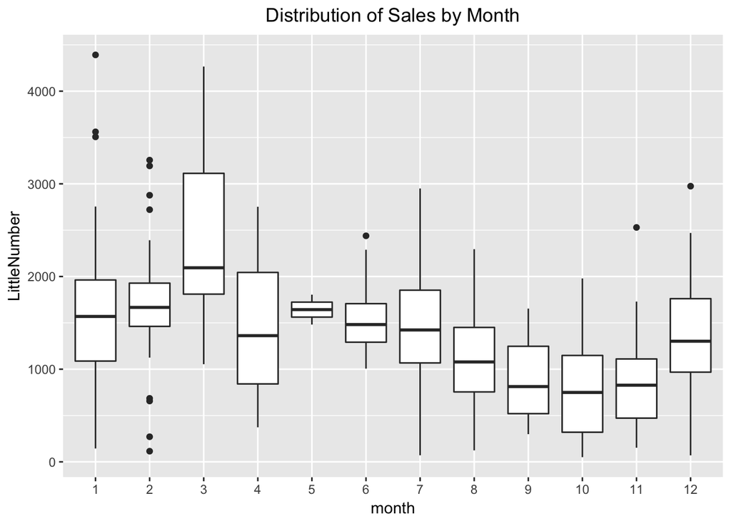

```r
garfs %>%
    ggplot(aes(month, LittleNumber)) +
    geom_boxplot() +
#    geom_hline(aes(yintercept = median(LittleNumber, na.rm = TRUE))) +
    ggtitle("Distribution of Sales by Month")
```

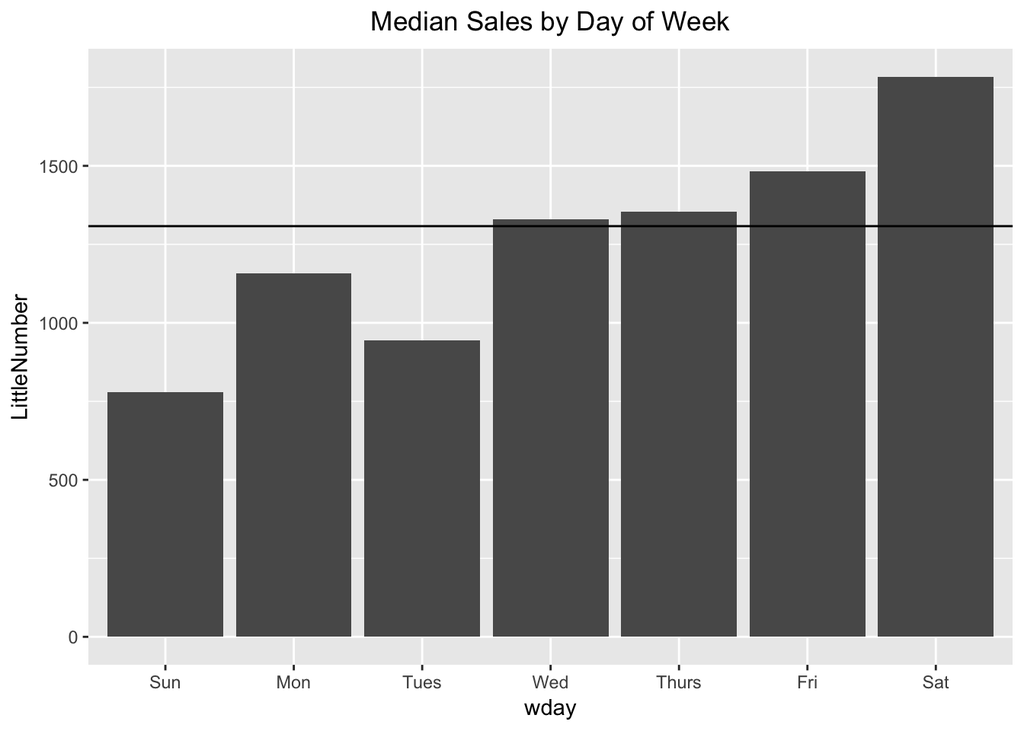

```r
garfs %>%
    ggplot(aes(wday, LittleNumber)) +
    stat_summary(fun.y = median, geom = "bar") +
    geom_hline(aes(yintercept = median(LittleNumber, na.rm = TRUE))) +
    ggtitle("Median Sales by Day of Week")
```

```r
garfs %>%
    group_by(wday) %>%
    summarise(median(LittleNumber, na.rm = TRUE), mean(LittleNumber, na.rm = TRUE))
```

| wday | median(LittleNumber, na.rm = TRUE) | mean(LittleNumber, na.rm = TRUE) |
| --- | --- | --- |
| Sun | 778.125 | 1500.028 |
| Mon | 1158.000 | 1201.741 |
| Tues | 943.500 | 1137.866 |
| Wed | 1328.965 | 1396.162 |
| Thurs | 1354.750 | 1332.932 |
| Fri | 1481.500 | 1601.445 |
| Sat | 1783.625 | 1836.017 |

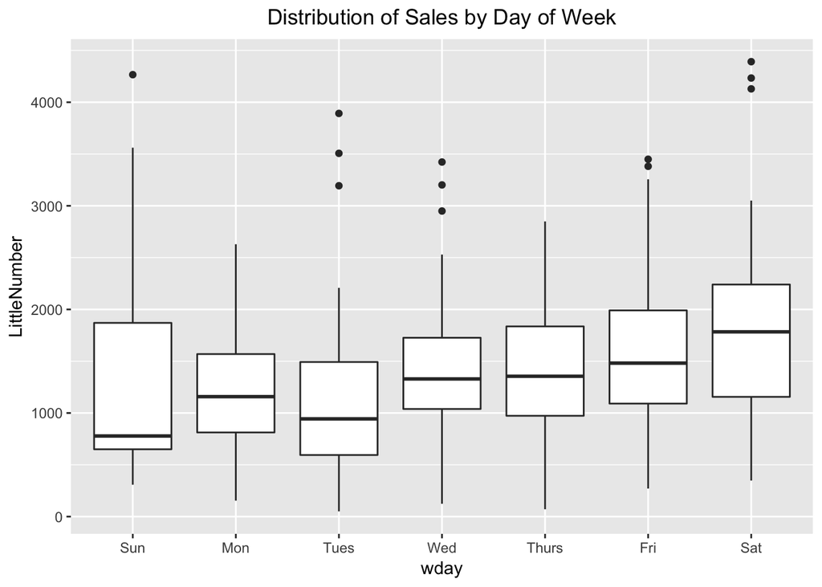

```r
garfs %>%
    ggplot(aes(wday, LittleNumber)) +
    geom_boxplot() +
#    geom_hline(aes(yintercept = median(LittleNumber, na.rm = TRUE))) +
    ggtitle("Distribution of Sales by Day of Week")
```

When identifying outliers, I will arbitrarily call anything lower than **500** or higher than **2000** an outlier.

```r
garfs %>%
    filter(LittleNumber < 500)
```

| Date | BigNumber | LittleNumber | NegDrop | Dinner | Shift | CutTime | Made | Comments | NegDropPaid(1/0) | percent_little | percent_big | month | year | wday |
| --- | --- | --- | --- | --- | --- | --- | --- | --- | --- | --- | --- | --- | --- | --- |
| 2017-07-06 | 438.27 | 399.25 | NA | 0 | pm | 7 | 81 | cut early | NA | 0.20288040 | 0.18481758 | 7 | 2017 | Thurs |
| 2017-07-10 | 379.48 | 369.50 | NA | 0 | pm | NA | 48 | NA | NA | 0.12990528 | 0.12648888 | 7 | 2017 | Mon |
| 2017-07-13 | 55.30 | 71.00 | -11.00 | 0 | pm | 5 | 6 | cut early | NA | 0.08450704 | 0.10849910 | 7 | 2017 | Thurs |
| 2017-08-20 | 253.72 | 347.50 | -41.77 | 1 | pm | NA | 76 | NA | 10 short on tote check (or 8/15) | 0.21870504 | 0.29954280 | 8 | 2017 | Sun |
| 2017-08-23 | 158.28 | 124.00 | NA | 0 | pm | 6 | 24 | cut early | NA | 0.19354839 | 0.15163002 | 8 | 2017 | Wed |
| 2017-09-04 | 637.17 | 496.50 | -67.03 | 0 | pm | 7 | 92 | cut early | 1 | 0.18529708 | 0.14438847 | 9 | 2017 | Mon |
| 2017-10-01 | 333.95 | 308.03 | NA | 0 | pm | 6 | 44 | cut early | NA | 0.14284323 | 0.13175625 | 10 | 2017 | Sun |
| 2017-10-02 | 532.38 | 499.52 | NA | 1 | pm | NA | 83 | NA | NA | 0.16615951 | 0.15590368 | 10 | 2017 | Mon |
| 2017-10-09 | 427.24 | 331.17 | -79.00 | 0 | pm | NA | 81 | NA | 1 | 0.24458737 | 0.18958899 | 10 | 2017 | Mon |
| 2017-11-14 | 408.58 | 420.75 | -22.85 | 0 | pm | 7 | 74 | cut early | 1 | 0.17587641 | 0.18111508 | 11 | 2017 | Tues |

[output cut: 26 more lines]

```r
garfs %>%
    filter(LittleNumber > 2000)
```

| Date | BigNumber | LittleNumber | NegDrop | Dinner | Shift | CutTime | Made | Comments | NegDropPaid(1/0) | percent_little | percent_big | month | year | wday |
| --- | --- | --- | --- | --- | --- | --- | --- | --- | --- | --- | --- | --- | --- | --- |
| 2018-01-02 | 3775.63 | 3506.75 | -278.64 | 1 | dub | NA | 523 | double | 1 | 0.1491409 | 0.13851993 | 1 | 2018 | Tues |
| 2018-01-05 | 2968.32 | 2755.00 | NA | 0 | dub | NA | 413 | NA | NA | 0.1499093 | 0.13913594 | 1 | 2018 | Fri |
| 2018-01-12 | 2591.36 | 2417.50 | NA | 0 | dub | NA | 334 | double but cut around 7 | NA | 0.1381593 | 0.12888985 | 1 | 2018 | Fri |
| 2018-01-21 | 3735.21 | 3561.25 | -34.66 | 0 | dub | NA | 573 | double | 1 | 0.1608986 | 0.15340503 | 1 | 2018 | Sun |
| 2018-01-31 | 2280.25 | 2176.25 | -109.70 | 0 | pm | NA | 463 | NA | NA | 0.2127513 | 0.20304791 | 1 | 2018 | Wed |
| 2018-02-09 | 3529.10 | 3256.00 | NA | 0 | dub | NA | 544 | double | NA | 0.1670762 | 0.15414695 | 2 | 2018 | Fri |
| 2018-02-23 | 2328.58 | 2154.00 | NA | 1 | pm | NA | 469 | 40 from apres | NA | 0.2177344 | 0.20141030 | 2 | 2018 | Fri |
| 2018-02-27 | 3425.54 | 3193.75 | NA | 0 | dub | NA | 554 | NA | NA | 0.1734638 | 0.16172633 | 2 | 2018 | Tues |
| 2018-03-02 | 3709.34 | 3449.50 | NA | 0 | swing | NA | 622 | NA | NA | 0.1803160 | 0.16768482 | 3 | 2018 | Fri |
| 2018-03-03 | 4559.27 | 4233.50 | -99.53 | 0 | swing | NA | 675 | NA | 1 | 0.1594425 | 0.14805002 | 3 | 2018 | Sat |

[output cut: 47 more lines]

## Cuts

I recognize that getting cut is one of the primary reasons I have bad shifts, and that it is also one of the biggest things holding back my average take-home.

To begin, here is a table breaking down when I got cut (if at all) and how much I made on average.

```r
garfs %>%
    filter(Shift == "pm") %>%
    group_by(CutTime) %>%
    summarise(n(), mean(Made))
```

| CutTime | n() | mean(Made) |
| --- | --- | --- |
| 5 | 2 | 6.50000 |
| 6 | 9 | 29.11111 |
| 7 | 13 | 59.30769 |
| 8 | 14 | 144.00000 |
| 9 | 5 | 131.80000 |
| NA | 219 | 220.58447 |

A look at the average impact of getting cut:

```r
(mean_all <- garfs %>%
    summarise(`Mean of all shifts` = mean(Made)))
```

| Mean of all shifts |
| --- |
| 241.4258 |

```r
(mean_no_cuts <- garfs %>%
    filter(is.na(CutTime)) %>%
    summarise(`Mean of full shifts` = mean(Made)))
```

| Mean of full shifts |
| --- |
| 259.7299 |

```r
(mean_cuts <- garfs %>%
    filter(!is.na(CutTime)) %>%
    summarise(`Mean of cuts` = mean(Made), n()))
```

| Mean of cuts | n() |
| --- | --- |
| 134.0189 | 53 |

## Miscellaneous

I work mostly nights, but here’s a look at how things break down between days, nights, and doubles:

```r
garfs %>%
    group_by(Shift) %>%
    summarise(count = n(), percent_n = round((count / nrow(garfs) * 100), digits = 1), mean(Made), median(Made))
```

| Shift | count | percent_n | mean(Made) | median(Made) |
| --- | --- | --- | --- | --- |
| am | 29 | 8.0 | 309.3103 | 302.0 |
| am bar | 1 | 0.3 | 331.0000 | 331.0 |
| apres | 1 | 0.3 | 117.0000 | 117.0 |
| day swing | 1 | 0.3 | 339.0000 | 339.0 |
| dub | 9 | 2.5 | 509.0000 | 544.0 |
| pm | 262 | 72.0 | 198.5840 | 189.0 |
| pm bar | 43 | 11.8 | 309.0930 | 308.0 |
| swing | 18 | 4.9 | 456.7222 | 439.5 |

Percentage of time I bought dinner while working:

```r
garfs %>%
    summarise(mean(Dinner))
```

| mean(Dinner) |
| --- |
| NA |

Total made since June 8, 2017:

```r
garfs %>%
    summarise(sum(Made))
```

| sum(Made) |
| --- |
| 87879 |

### Things to add:

- Add headers to make slides
- Break down by season (and also year)